# PSI_Assignment 1: Digital Portfolio: Prepare and Explore Parts

Na Li (D19125334)

```r
knitr::opts_chunk$set(echo = TRUE)

needed_packages <- c("VIM", "tidyverse","pastecs", "ggplot2", "semTools", "psych", "FSA", "car", "effectsize", "coin", "rstatix", "sjstats", "userfriendlyscience", "stats", "foreign", "gmodels")
# Extract not installed packages
not_installed <- needed_packages[!(needed_packages %in% installed.packages()[, "Package"])]
# Install not installed packages
if(length(not_installed)) install.packages(not_installed)

library(pastecs) #For creating descriptive statistic summaries
library(ggplot2) #For creating histograms with more detail than plot
library(semTools) #For skewness and kurtosis
library(psych)  #For descriptive functions
library(FSA) #For percentage
library(car) # For Levene's test for homogeneity of variance
library(effectsize) #To calculate effect size for t-test
library(VIM)
library(tidyverse)
library(coin) # For Wilcox test (non-parametric)
library(rstatix) # For calculating effect size
library(sjstats) #calculate effect size for t-test
library(userfriendlyscience)
library(stats)
library(foreign) # open SPSS file, I may not use that.
library(gmodels) #For creating histograms with more detail than plot
```

# Understanding Dataset

This dataset is Secondary School student Performance in secondary education of two Portuguese schools, in this secion, 1. Merged data set from two csv files (student-mat.csv (Math course) and student-por.csv (Portuguese language course) datasets), account the number of data set as a sample data. 2. Visualising Quantitative Data 3. Visualising Qualitative Data

```r
getwd()
```

```
## [1] "/home/d19125334/Documents/PhD_Modules_2021/ProbilityandStatisiticInference/assignment/assignment1/Assignment1"
```

```r
stdMathData=read.table("student-mat.csv",sep=";",header=TRUE) #read student
stdPorlagData=read.table("student-por.csv",sep=";",header=TRUE)

stdMergeData=merge(stdMathData,stdPorlagData,by=c("school","sex","age","address","famsize","Pstatus","Medu","Fedu","Mjob","Fjob","reason","nursery","internet"))

#total number of the dataset
print(nrow(stdMergeData)) # 382 records/rows/cases
```

```
## [1] 382
```

```r
#number of students math course -> 395 records
nrow(stdMathData)
```

```
## [1] 395
```

```r
#number of students for Portuguese language course -> 649 records
nrow(stdPorlagData)
```

```
## [1] 649
```

```r
colnames(stdMathData) <- tolower(colnames(stdMathData))
colnames(stdPorlagData) <- tolower(colnames(stdPorlagData))
colnames(stdMergeData) <- tolower(colnames(stdMergeData))

write.csv(x=stdMergeData, file="student_merged.csv")

#show variables in three datasets
colnames(stdMathData)
```

```
##  [1] "school"     "sex"        "age"        "address"    "famsize"
##  [6] "pstatus"    "medu"       "fedu"       "mjob"       "fjob"
## [11] "reason"     "guardian"   "traveltime" "studytime"  "failures"
## [16] "schoolsup"  "famsup"     "paid"       "activities" "nursery"
## [21] "higher"     "internet"   "romantic"   "famrel"     "freetime"
## [26] "goout"      "dalc"       "walc"       "health"     "absences"
## [31] "g1"         "g2"         "g3"
```

```r
colnames(stdPorlagData)
```

```
##  [1] "school"     "sex"        "age"        "address"    "famsize"
##  [6] "pstatus"    "medu"       "fedu"       "mjob"       "fjob"
## [11] "reason"     "guardian"   "traveltime" "studytime"  "failures"
## [16] "schoolsup"  "famsup"     "paid"       "activities" "nursery"
## [21] "higher"     "internet"   "romantic"   "famrel"     "freetime"
## [26] "goout"      "dalc"       "walc"       "health"     "absences"
## [31] "g1"         "g2"         "g3"
```

```r
colnames(stdMergeData)
```

```
##  [1] "school"       "sex"          "age"          "address"      "famsize"
##  [6] "pstatus"      "medu"         "fedu"         "mjob"         "fjob"
## [11] "reason"       "nursery"      "internet"     "guardian.x"   "traveltime.x"
## [16] "studytime.x"  "failures.x"   "schoolsup.x"  "famsup.x"     "paid.x"
## [21] "activities.x" "higher.x"     "romantic.x"   "famrel.x"     "freetime.x"
## [26] "goout.x"      "dalc.x"       "walc.x"       "health.x"     "absences.x"
## [31] "g1.x"         "g2.x"         "g3.x"         "guardian.y"   "traveltime.y"
## [36] "studytime.y"  "failures.y"   "schoolsup.y"  "famsup.y"     "paid.y"
## [41] "activities.y" "higher.y"     "romantic.y"   "famrel.y"     "freetime.y"
## [46] "goout.y"      "dalc.y"       "walc.y"       "health.y"     "absences.y"
## [51] "g1.y"         "g2.y"         "g3.y"
```

## Qualitative Data

```r
# Looking at interest variables in two Samples: sex, mother jobs, father job, reason
# Qualitative data

stdMathData$sex <- as.factor(stdMathData$sex)
stdPorlagData$sex <- as.factor(stdPorlagData$sex)
stdMergeData$sex <- as.factor(stdMergeData$sex)

summary(stdMathData$sex)
```

```
##   F   M
## 208 187
```

```r
summary(stdPorlagData$sex)
```

```
##   F   M
## 383 266
```

```r
summary(stdMergeData$sex)
```

```
##   F   M
## 198 184
```

```r
# Looking at interest variables in two Samples: sex, mother jobs, father job, reason
# Qualitative data

stdMathData$mjob <- as.factor(stdMathData$mjob)
stdPorlagData$mjob <- as.factor(stdPorlagData$mjob)

summary(stdMathData$mjob)
```

```
##  at_home   health    other services  teacher
##       59       34      141      103       58
```

```r
summary(stdPorlagData$mjob)
```

```
##  at_home   health    other services  teacher
##      135       48      258      136       72
```

```r
# Looking at interest variables in two Samples: sex, mother jobs, father job, reason
# Qualitative dataset
stdMathData$fjob <- as.factor(stdMathData$fjob)
stdPorlagData$fjob <- as.factor(stdPorlagData$fjob)

summary(stdMathData$fjob)
```

```
##  at_home   health    other services  teacher
##       20       18      217      111       29
```

```r
summary(stdPorlagData$fjob)
```

```
##  at_home   health    other services  teacher
##       42       23      367      181       36
```

```r
# Looking at interest variables in two Samples: address
# Qualitative data
stdMathData$address <- as.factor(stdMathData$address)
stdPorlagData$address <- as.factor(stdPorlagData$address)
# Student data for Math course: reason to choose this school
summary(stdMathData$address)
```

```
##   R   U
##  88 307
```

```r
# Student data for Portuguese language course: reason to choose this school
summary(stdPorlagData$address)
```

```
##   R   U
## 197 452
```

```r
# Looking at interest variables in two Samples: family educational support
# Qualitative data
stdMathData$famsup <- as.factor(stdMathData$famsup)
stdPorlagData$famsup <- as.factor(stdPorlagData$famsup)
# Math course
str(stdMathData$famsup)
```

```
##  Factor w/ 2 levels "no","yes": 1 2 1 2 2 2 1 2 2 2 ...
```

```r
summary(stdMathData$famsup)
```

```
##  no yes
## 153 242
```

```r
# Looking at interest variables in two Samples: family educational support
# Qualitative data
# Portuguese language course
str(stdPorlagData$famsup)
```

```
##  Factor w/ 2 levels "no","yes": 1 2 1 2 2 2 1 2 2 2 ...
```

```r
summary(stdPorlagData$famsup)
```

```
##  no yes
## 251 398
```

```r
# Looking at interest variables in two Samples: with a romantic relationship
# Qualitative data
stdMathData$romantic <- as.factor(stdMathData$romantic)
stdPorlagData$romantic <- as.factor(stdPorlagData$romantic)
# Math course
str(stdMathData$romantic)
```

```
##  Factor w/ 2 levels "no","yes": 1 1 1 2 1 1 1 1 1 1 ...
```

```r
summary(stdMathData$romantic)
```

```
##  no yes
## 263 132
```

```r
# Looking at interest variables in two Samples: with a romantic relationship
# Qualitative data
# Portuguese language course
str(stdPorlagData$romantic)
```

```
##  Factor w/ 2 levels "no","yes": 1 1 1 2 1 1 1 1 1 1 ...
```

```r
summary(stdPorlagData$romantic)
```

```
##  no yes
## 410 239
```

## Quantitative Data

Looking at interest quantitativ data of variables in two samples: traveltime, studytime, G1 - G3 (grade 1 to grade 3), ### Measure of Central Tendency:mean, median, mode

```r
#traveltime: math course
mean(stdMathData$traveltime)
```

```
## [1] 1.448101
```

```r
#traeltime: portuguese language course
mean(stdPorlagData$traveltime)
```

```
## [1] 1.568567
```

```r
#traveltime: math course
median(stdMathData$traveltime)
```

```
## [1] 1
```

```r
#traeltime: portuguese language course
median(stdPorlagData$traveltime)
```

```
## [1] 1
```

```r
#traveltime: math course
getmode <- function(v) {
   uniqv <- unique(v)
   uniqv[which.max(tabulate(match(v, uniqv)))]
}

getmode(stdMathData$traveltime)
```

```
## [1] 1
```

```r
#traeltime: portuguese language course
getmode(stdPorlagData$traveltime)
```

```
## [1] 1
```

```r
#traveltime: math course
summary(stdMathData$traveltime)
```

```
##    Min. 1st Qu.  Median    Mean 3rd Qu.    Max.
##   1.000   1.000   1.000   1.448   2.000   4.000
```

```r
#traeltime: portuguese language course
summary(stdPorlagData$traveltime)
```

```
##    Min. 1st Qu.  Median    Mean 3rd Qu.    Max.
##   1.000   1.000   1.000   1.569   2.000   4.000
```

```r
#studytime: math course
summary(stdMathData$studytime)
```

```
##    Min. 1st Qu.  Median    Mean 3rd Qu.    Max.
##   1.000   1.000   2.000   2.035   2.000   4.000
```

```r
#studytime: portuguese language course
summary(stdPorlagData$studytime)
```

```
##    Min. 1st Qu.  Median    Mean 3rd Qu.    Max.
##   1.000   1.000   2.000   1.931   2.000   4.000
```

```r
#studytime: math course
getmode(stdMathData$studytime)
```

```
## [1] 2
```

```r
#studytime: portuguese language course
getmode(stdPorlagData$studytime)
```

```
## [1] 2
```

```r
#studytime: math course
summary(stdMathData$g1)
```

```
##    Min. 1st Qu.  Median    Mean 3rd Qu.    Max.
##    3.00    8.00   11.00   10.91   13.00   19.00
```

```r
#studytime: portuguese language course
summary(stdPorlagData$g1)
```

```
##    Min. 1st Qu.  Median    Mean 3rd Qu.    Max.
##     0.0    10.0    11.0    11.4    13.0    19.0
```

```r
#G1: math course
getmode(stdMathData$g1)
```

```
## [1] 10
```

```r
#G1: portuguese language course
getmode(stdPorlagData$g1)
```

```
## [1] 10
```

```r
#studytime: math course
summary(stdMathData$g2)
```

```
##    Min. 1st Qu.  Median    Mean 3rd Qu.    Max.
##    0.00    9.00   11.00   10.71   13.00   19.00
```

```r
#studytime: portuguese language course
summary(stdPorlagData$g2)
```

```
##    Min. 1st Qu.  Median    Mean 3rd Qu.    Max.
##    0.00   10.00   11.00   11.57   13.00   19.00
```

```r
#G2: math course
getmode(stdMathData$g2)
```

```
## [1] 9
```

```r
#G2: portuguese language course
getmode(stdPorlagData$g2)
```

```
## [1] 11
```

```r
#studytime: math course
summary(stdMathData$g3)
```

```
##    Min. 1st Qu.  Median    Mean 3rd Qu.    Max.
##    0.00    8.00   11.00   10.42   14.00   20.00
```

```r
#studytime: portuguese language course
summary(stdPorlagData$g3)
```

```
##    Min. 1st Qu.  Median    Mean 3rd Qu.    Max.
##    0.00   10.00   12.00   11.91   14.00   19.00
```

```r
#G3: math course
getmode(stdMathData$g3)
```

```
## [1] 10
```

```r
#G3: portuguese language course
getmode(stdPorlagData$g3)
```

```
## [1] 11
```

### Measure of Dispersion (descriptive statistics): range, quantiles, standard deviation (sd), IQR

```r
#G1: math course
round(sd(as.double(stdMathData$g1)),2)
```

```
## [1] 3.32
```

```r
#G1: portuguese language course
round(sd(as.double(stdPorlagData$g1)),2)
```

```
## [1] 2.75
```

```r
#G2: math course
round(sd(as.double(stdMathData$g2)),2)
```

```
## [1] 3.76
```

```r
#G2: portuguese language course
round(sd(as.double(stdPorlagData$g2)),2)
```

```
## [1] 2.91
```

```r
#G3: math course
sdMathData_g3 <- sd(as.double(stdMathData$g3))
round(sdMathData_g3, 2)
```

```
## [1] 4.58
```

```r
#G3: portuguese language course
sdPorlagData_g3 <- sd(as.double(stdPorlagData$g3))
round(sdPorlagData_g3,2)
```

```
## [1] 3.23
```

```r
#math course
range(as.double(stdMathData$g1))
```

```
## [1]  3 19
```

```r
quantile(as.double(stdMathData$g1))
```

```
##   0%  25%  50%  75% 100%
##    3    8   11   13   19
```

```r
IQR(as.double(stdMathData$g1))
```

```
## [1] 5
```

```r
var(as.double(stdMathData$g1))
```

```
## [1] 11.01705
```

```r
#portuguese language course
range(as.double(stdPorlagData$g1))
```

```
## [1]  0 19
```

```r
quantile(as.double(stdPorlagData$g1))
```

```
##   0%  25%  50%  75% 100%
##    0   10   11   13   19
```

```r
IQR(as.double(stdPorlagData$g1))
```

```
## [1] 3
```

```r
var(as.double(stdPorlagData$g1))
```

```
## [1] 7.536481
```

```r
#math course
range(as.double(stdMathData$g2))
```

```
## [1]  0 19
```

```r
quantile(as.double(stdMathData$g2))
```

```
##   0%  25%  50%  75% 100%
##    0    9   11   13   19
```

```r
IQR(as.double(stdMathData$g2))
```

```
## [1] 4
```

```r
var(as.double(stdMathData$g2))
```

```
## [1] 14.14892
```

```r
#portuguese language course
range(as.double(stdPorlagData$g2))
```

```
## [1]  0 19
```

```r
quantile(as.double(stdPorlagData$g2))
```

```
##   0%  25%  50%  75% 100%
##    0   10   11   13   19
```

```r
IQR(as.double(stdPorlagData$g2))
```

```
## [1] 3
```

```r
var(as.double(stdPorlagData$g2))
```

```
## [1] 8.48929
```

```r
#math course
range(as.double(stdMathData$g3))
```

```
## [1]  0 20
```

```r
quantile(as.double(stdMathData$g3))
```

```
##   0%  25%  50%  75% 100%
##    0    8   11   14   20
```

```r
IQR(as.double(stdMathData$g3))
```

```
## [1] 6
```

```r
var(as.double(stdMathData$g3))
```

```
## [1] 20.98962
```

```r
#Portuguese language course
range(as.double(stdPorlagData$g3))
```

```
## [1]  0 19
```

```r
quantile(as.double(stdPorlagData$g3))
```

```
##   0%  25%  50%  75% 100%
##    0   10   12   14   19
```

```r
IQR(as.double(stdPorlagData$g3))
```

```
## [1] 4
```

```r
var(as.double(stdPorlagData$g3))
```

```
## [1] 10.43714
```

### Visualising Quantitative Data

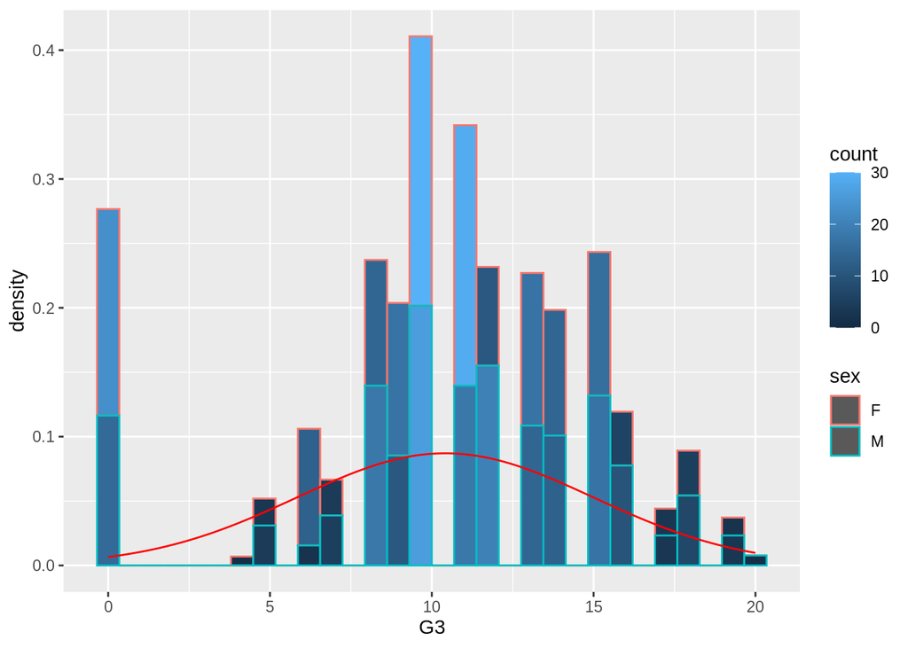

```r
gg_g3 <- ggplot(stdMathData, aes(x=stdMathData$g3))
gg_g3 <- gg_g3 + labs(x="G3")
gg_g3 <- gg_g3 + geom_histogram(bins = 30,aes(y=..density.., color=sex, fill=..count..))
   #geom_histogram(binwidth=2, colour="black", aes(y=..density.., fill=..count..))


#gg_g3 <- gg_g3 + scale_fill_gradient("Count", low="#DCDCDC", high="#7C7C7C")

gg_g3 <- gg_g3 + stat_function(fun=dnorm, color='red',args=list(mean=mean(stdMathData$g3, na.rm=TRUE), sd=sd(stdMathData$g3, na.rm=TRUE)))

gg_g3
```

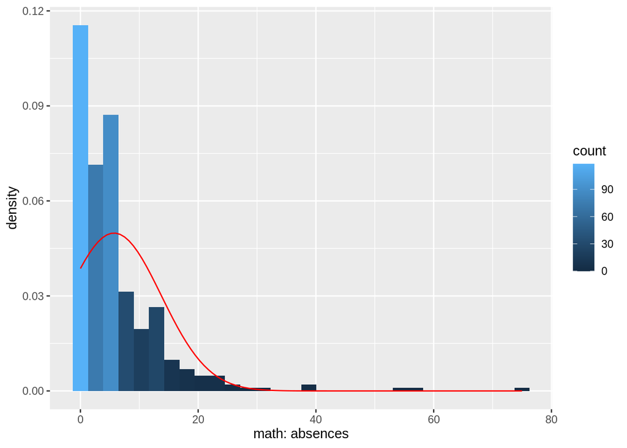

```r
ggplot(stdMathData, aes(x=stdMathData$absences)) +
         labs(x="math: absences") +
         geom_histogram(bins = 30,aes(y=..density.., fill=..count..)) +
         stat_function(fun=dnorm, color='red',args=list(mean=mean(stdMathData$absences, na.rm=TRUE), sd=sd(stdMathData$absences, na.rm=TRUE)))
```

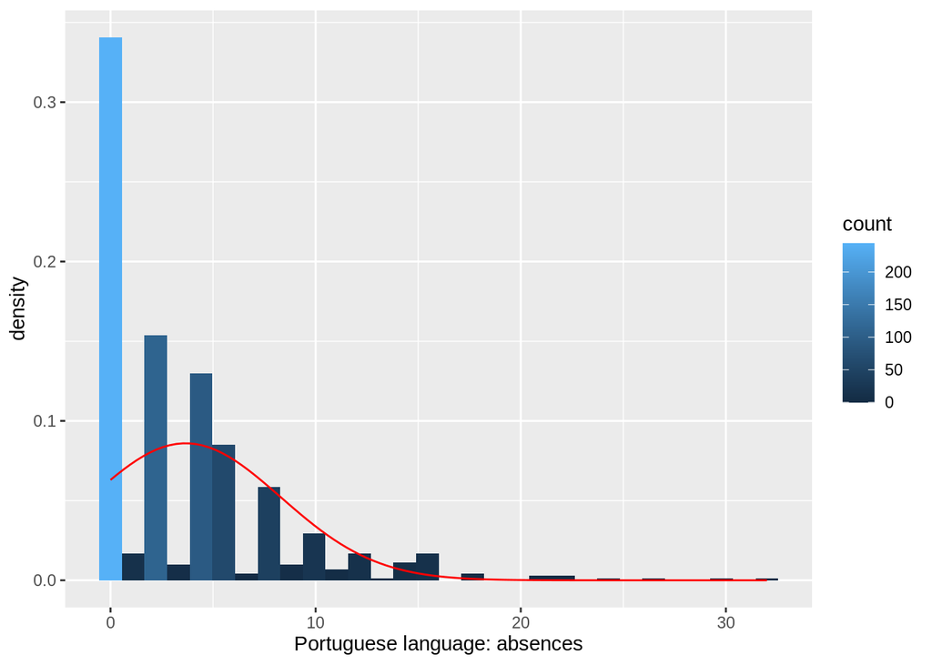

```r
gg_st <- ggplot(stdPorlagData, aes(x=stdPorlagData$absences))
gg_st <- gg_st + labs(x="Portuguese language: absences")
gg_st <- gg_st + geom_histogram(bins = 30,aes(y=..density.., fill=..count..))
gg_st <- gg_st + stat_function(fun=dnorm, color='red',args=list(mean=mean(stdPorlagData$absences, na.rm=TRUE), sd=sd(stdPorlagData$absences, na.rm=TRUE)))

gg_st
```

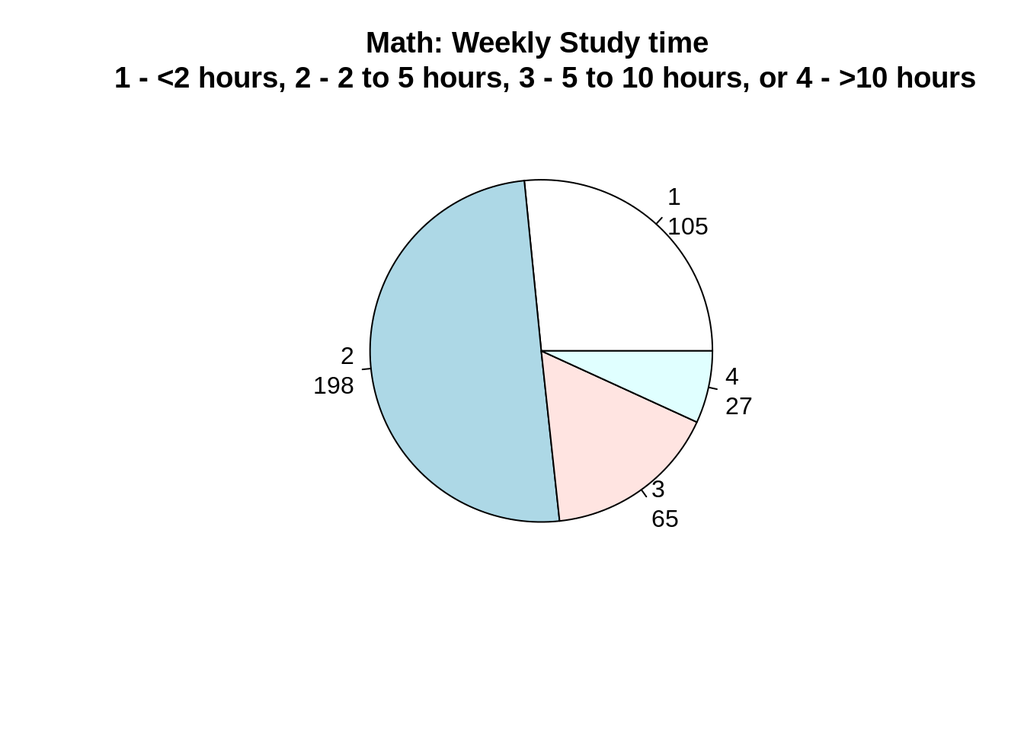

```r
#pie chart
mytable <- table(stdMathData$studytime)
lbls <- paste(names(mytable), "\n", mytable, sep="")
pie(mytable, labels = lbls,
   main="Math: Weekly Study time \n 1 - <2 hours, 2 - 2 to 5 hours, 3 - 5 to 10 hours, or 4 - >10 hours")
```

[figure not shown]

```r
# Pie Chart from data frame with Appended Sample Sizes
mytable_por <- table(stdPorlagData$studytime)
lbls <- paste(names(mytable_por), "\n", mytable_por, sep="")
pie(mytable, labels = lbls,
   main="Prtuguese language: Weekly Study time \n 1 - <2 hours, 2 - 2 to 5 hours, 3 - 5 to 10 hours, or 4 - >10 hours")
```

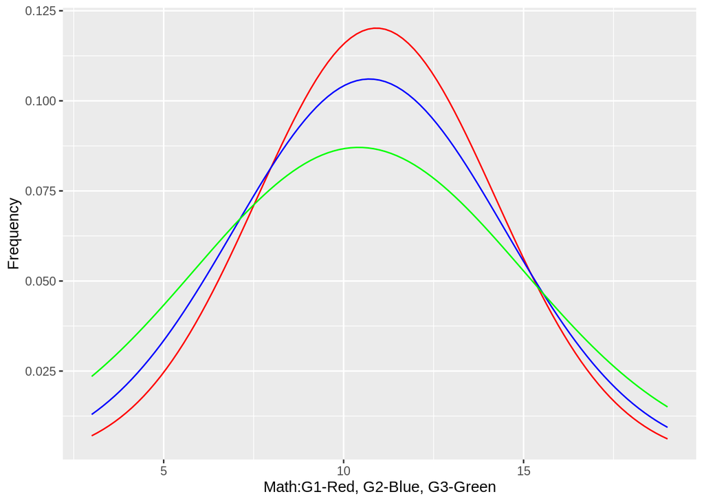

```r
gg_math <- ggplot(stdMathData, aes(x=stdMathData$g1))
gg_math <- gg_math + labs(x="Math:G1-Red, G2-Blue, G3-Green", y="Frequency")
gg_math <- gg_math + stat_function(fun=dnorm, color='red',args=list(mean=mean(stdMathData$g1, na.rm=TRUE), sd=sd(stdMathData$g1, na.rm=TRUE)))

gg_math <- gg_math + stat_function(fun=dnorm, color='blue',args=list(mean=mean(stdMathData$g2, na.rm=TRUE), sd=sd(stdMathData$g2, na.rm=TRUE)))


gg_math <- gg_math + stat_function(fun=dnorm, color='green',args=list(mean=mean(stdMathData$g3, na.rm=TRUE), sd=sd(stdMathData$g3, na.rm=TRUE)))

gg_math
```

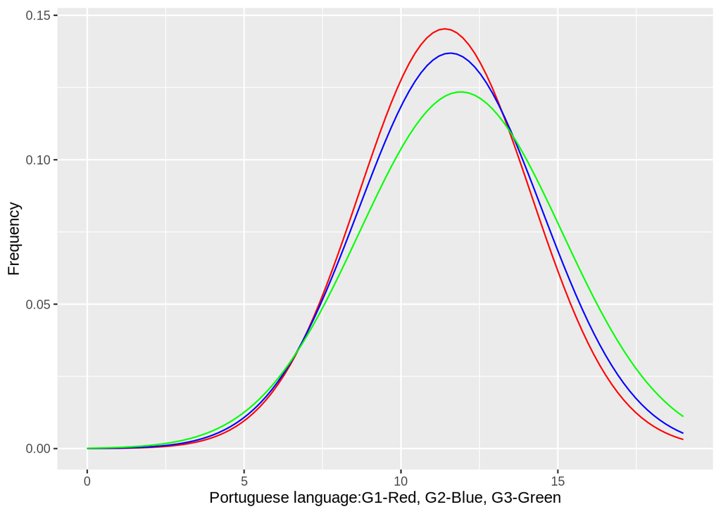

```r
gg_porlag <- ggplot(stdPorlagData, aes(x=stdPorlagData$g1))
gg_porlag <- gg_porlag + labs(x="Portuguese language:G1-Red, G2-Blue, G3-Green", y="Frequency")
gg_porlag <- gg_porlag + stat_function(fun=dnorm, color='red',args=list(mean=mean(stdPorlagData$g1, na.rm=TRUE), sd=sd(stdPorlagData$g1, na.rm=TRUE)))

gg_porlag <- gg_porlag + stat_function(fun=dnorm, color='blue',args=list(mean=mean(stdPorlagData$g2, na.rm=TRUE), sd=sd(stdPorlagData$g2, na.rm=TRUE)))


gg_porlag <- gg_porlag + stat_function(fun=dnorm, color='green',args=list(mean=mean(stdPorlagData$g3, na.rm=TRUE), sd=sd(stdPorlagData$g3, na.rm=TRUE)))

gg_porlag
```

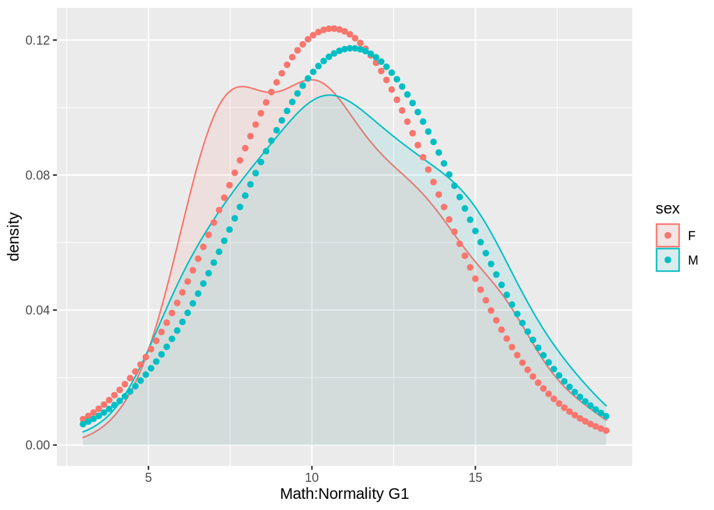

```r
female <- filter(stdMathData, sex == "F")
male <- filter(stdMathData, sex=="M")

gg_g1 <- ggplot(stdMathData, aes(x=g1, fill=sex, colour=sex)) + geom_density(alpha = 0.1)
gg_g1 <- gg_g1 + labs(x="Math:Normality G1")

gg_g1 <- gg_g1 + stat_function(data = female, geom = "point", fun=dnorm, args=list(mean=mean(female$g1, na.rm=TRUE), sd=sd(female$g1, na.rm=TRUE)))

gg_g1 <- gg_g1 + stat_function(data = male, geom = "point", fun=dnorm, args=list(mean=mean(male$g1, na.rm=TRUE), sd=sd(male$g1, na.rm=TRUE)))

gg_g1
```

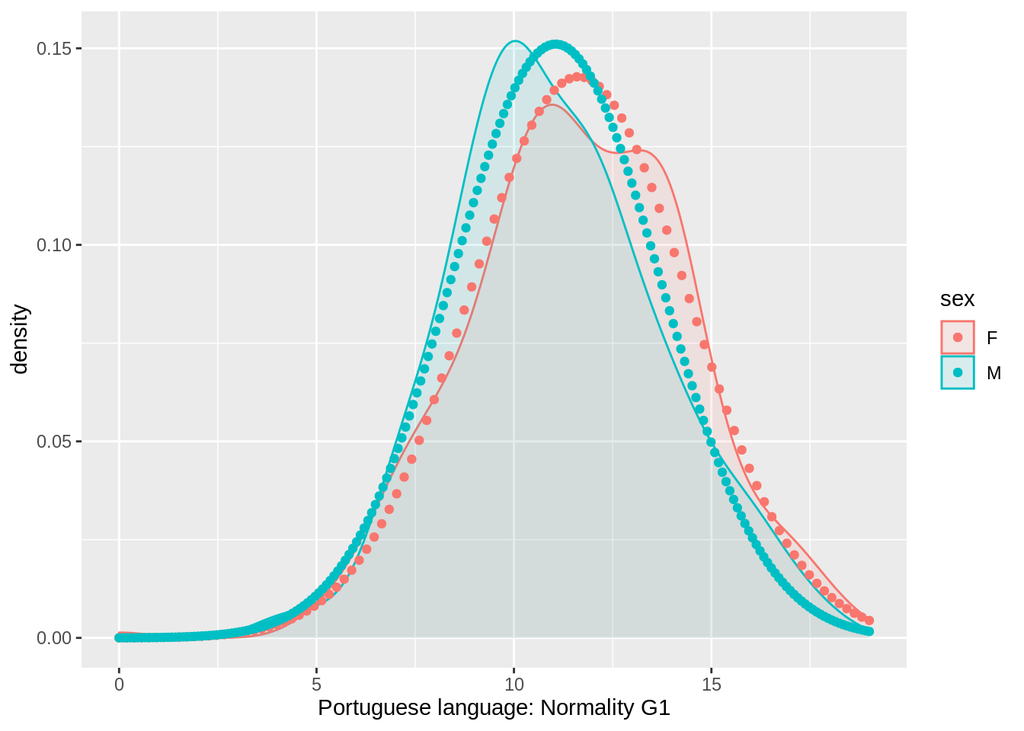

```r
library(ggplot2)

female <- filter(stdPorlagData, stdPorlagData$sex=="F")
male <- filter(stdPorlagData, stdPorlagData$sex=="M")

gg_g1 <- ggplot(stdPorlagData, aes(x=g1, fill=sex, colour=sex)) + geom_density(alpha = 0.1)
gg_g1 <- gg_g1 + labs(x="Portuguese language: Normality G1")

gg_g1 <- gg_g1 + stat_function(data = female, geom = "point", fun=dnorm, args=list(mean=mean(female$g1, na.rm=TRUE), sd=sd(female$g1, na.rm=TRUE)))

gg_g1 <- gg_g1 + stat_function(data = male, geom = "point", n=200, fun=dnorm, args=list(mean=mean(male$g1, na.rm=TRUE), sd=sd(male$g1, na.rm=TRUE)))

gg_g1
```

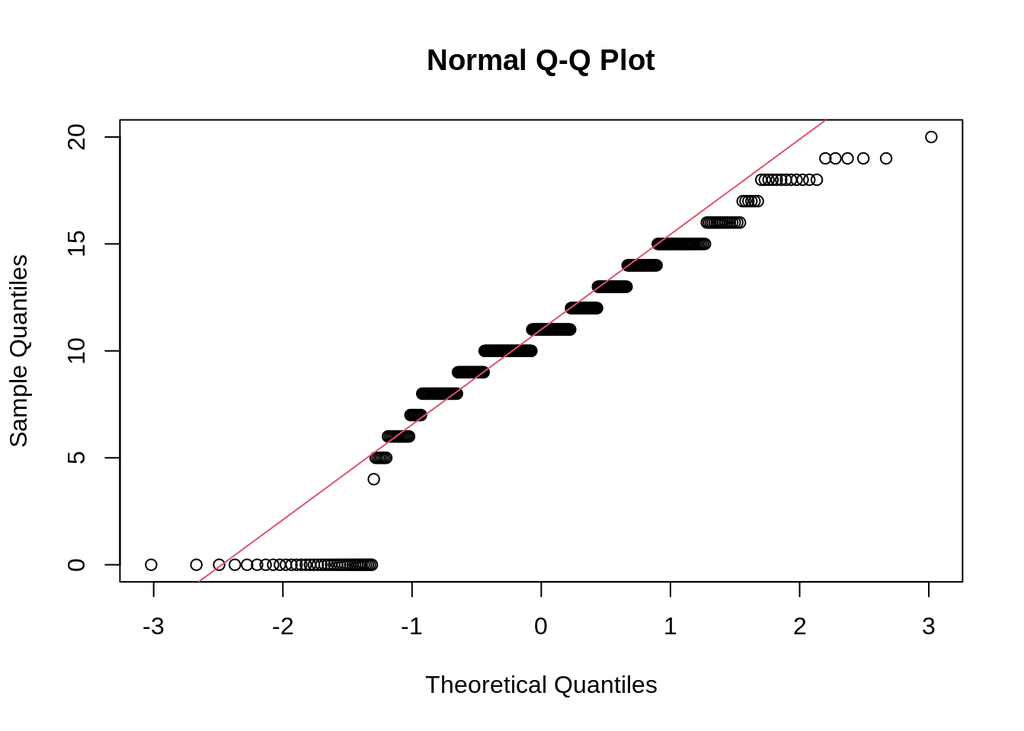

```r
#qq-plot
qqnorm(stdMathData$g3)
qqline(stdMathData$g3, col=2)
```

```r
library(pastecs)
pastecs::stat.desc(stdMathData$g3, basic=F)
```

```
##       median         mean      SE.mean CI.mean.0.95          var      std.dev
##   11.0000000   10.4151899    0.2305174    0.4531979   20.9896164    4.5814426
##     coef.var
##    0.4398809
```

```r
tpskew<-semTools::skew(stdMathData$g3)
tpkurt<-semTools::kurtosis(stdMathData$g3)
tpskew[1]/tpskew[2]
```

```
## skew (g1)
## -5.944738
```

```r
tpkurt[1]/tpkurt[2]
```

```
## Excess Kur (g2)
##        1.636633
```

```r
ztpcoiss<- abs(scale(stdMathData$g3))
FSA::perc(as.numeric(ztpcoiss), 1.96, "gt")
```

```
## [1] 9.873418
```

```r
FSA::perc(as.numeric(ztpcoiss), 3.29, "gt")
```

```
## [1] 0
```

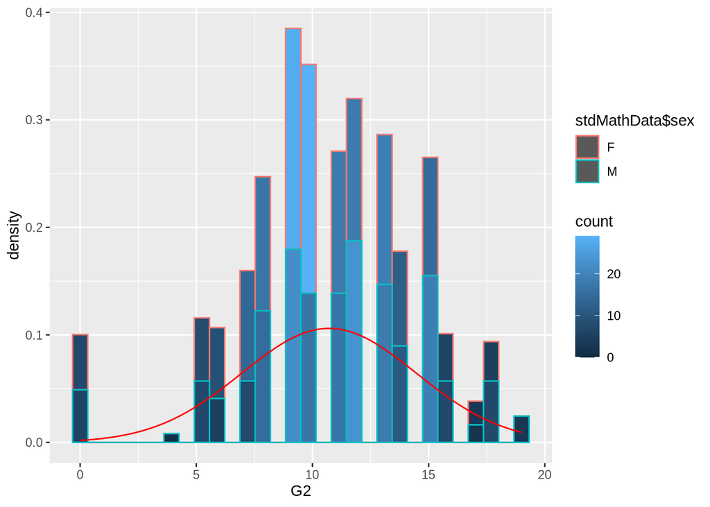

```r
gg_g2 <- ggplot(stdMathData, aes(x=stdMathData$g2))
gg_g2 <- gg_g2 + labs(x="G2")
gg_g2 <- gg_g2 + geom_histogram(bins = 30,aes(y=..density.., fill=..count..,color=stdMathData$sex))
#gg_g2 <- gg_g2 + scale_fill_gradient("Count", low="#DCDCDC", high="#7C7C7C")

gg_g2 <- gg_g2 + stat_function(fun=dnorm, color="red",args=list(mean=mean(stdMathData$g2, na.rm=TRUE), sd=sd(stdMathData$g2, na.rm=TRUE)))

gg_g2
```

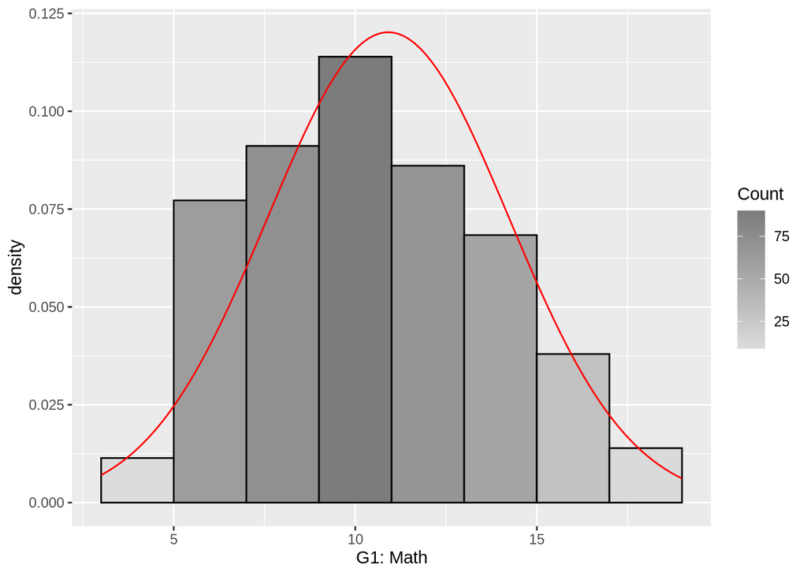

```r
gg_g1 <- ggplot(stdMathData, aes(x=g1))
gg_g1 <- gg_g1 + labs(x="G1: Math")
gg_g1 <- gg_g1 + geom_histogram(binwidth=2, colour="black", aes(y=..density.., fill=..count..))
gg_g1 <- gg_g1 + scale_fill_gradient("Count", low="#DCDCDC", high="#7C7C7C")

gg_g1 <- gg_g1 + stat_function(fun=dnorm, color="red",args=list(mean=mean(stdMathData$g1, na.rm=TRUE), sd=sd(stdMathData$g1, na.rm=TRUE)))

gg_g1
```

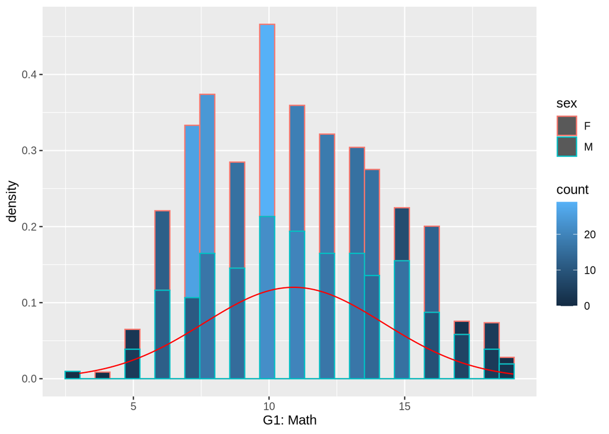

```r
library(ggplot2)
gg_g1 <- ggplot(stdMathData, aes(x=stdMathData$g1))
gg_g1 <- gg_g1 + labs(x="G1: Math")
gg_g1 <- gg_g1 + geom_histogram(bins = 30,aes(y=..density.., color=sex, fill=..count..))
gg_g1 <- gg_g1 + stat_function(fun=dnorm, color="red",args=list(mean=mean(stdMathData$g1, na.rm=TRUE), sd=sd(stdMathData$g1, na.rm=TRUE)))

gg_g1
```

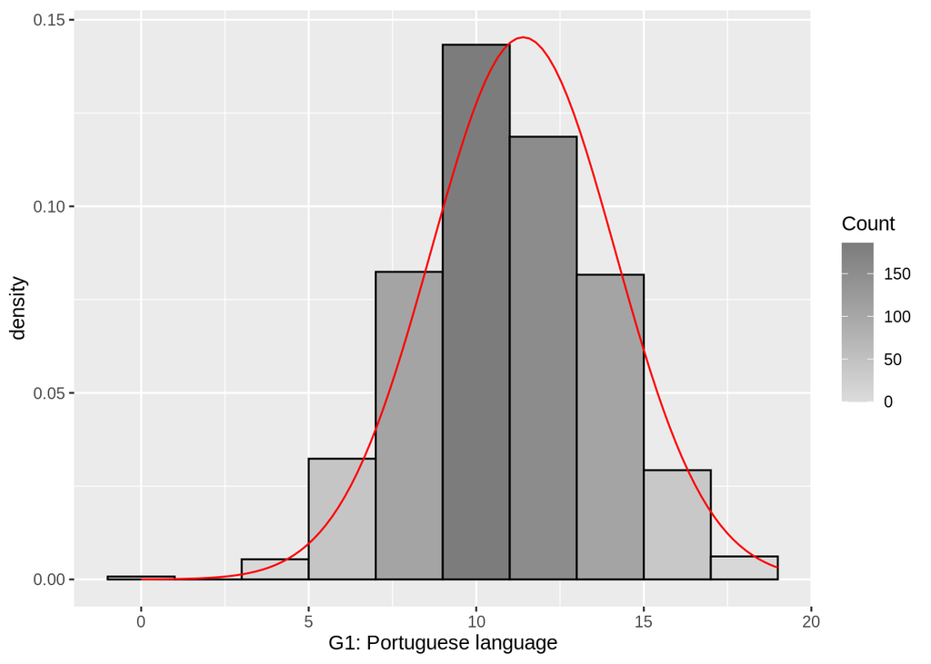

```r
gg_g1 <- ggplot(stdPorlagData, aes(x=g1))
gg_g1 <- gg_g1 + labs(x="G1: Portuguese language")
gg_g1 <- gg_g1 + geom_histogram(binwidth=2, colour="black", aes(y=..density.., fill=..count..))
gg_g1 <- gg_g1 + scale_fill_gradient("Count", low="#DCDCDC", high="#7C7C7C")

gg_g1 <- gg_g1 + stat_function(fun=dnorm, color="red",args=list(mean=mean(stdPorlagData$g1, na.rm=TRUE), sd=sd(stdPorlagData$g1, na.rm=TRUE)))

gg_g1
```

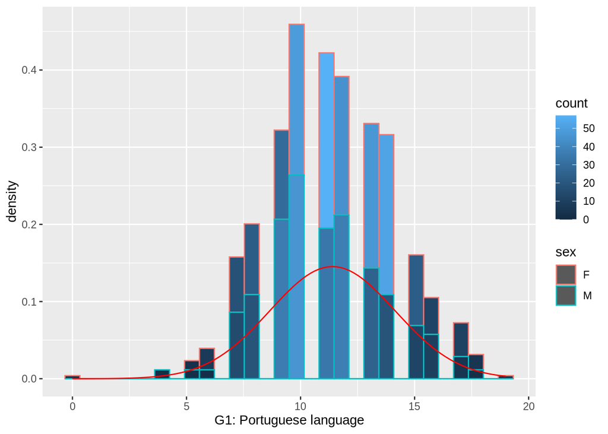

```r
gg_g1 <- ggplot(stdPorlagData, aes(x=stdPorlagData$g1))
gg_g1 <- gg_g1 + labs(x="G1: Portuguese language")
gg_g1 <- gg_g1 + geom_histogram(bins = 30,aes(y=..density.., color=sex, fill=..count..))
gg_g1 <- gg_g1 + stat_function(fun=dnorm, color="red",args=list(mean=mean(stdPorlagData$g1, na.rm=TRUE), sd=sd(stdPorlagData$g1, na.rm=TRUE)))

gg_g1
```

### Missing Data

```r
variableint <- c("g1", "g2", "g3", "studytime", "traveltime", "health", "absences", "famrel", "freetime")
subdata_math <-stdMathData[variableint]
subdata_por <- stdPorlagData[variableint]
summary(subdata_math)
```

```
##        g1              g2              g3          studytime
##  Min.   : 3.00   Min.   : 0.00   Min.   : 0.00   Min.   :1.000
##  1st Qu.: 8.00   1st Qu.: 9.00   1st Qu.: 8.00   1st Qu.:1.000
##  Median :11.00   Median :11.00   Median :11.00   Median :2.000
##  Mean   :10.91   Mean   :10.71   Mean   :10.42   Mean   :2.035
##  3rd Qu.:13.00   3rd Qu.:13.00   3rd Qu.:14.00   3rd Qu.:2.000
##  Max.   :19.00   Max.   :19.00   Max.   :20.00   Max.   :4.000
##    traveltime        health         absences          famrel
##  Min.   :1.000   Min.   :1.000   Min.   : 0.000   Min.   :1.000
##  1st Qu.:1.000   1st Qu.:3.000   1st Qu.: 0.000   1st Qu.:4.000
##  Median :1.000   Median :4.000   Median : 4.000   Median :4.000
##  Mean   :1.448   Mean   :3.554   Mean   : 5.709   Mean   :3.944
##  3rd Qu.:2.000   3rd Qu.:5.000   3rd Qu.: 8.000   3rd Qu.:5.000
##  Max.   :4.000   Max.   :5.000   Max.   :75.000   Max.   :5.000
##     freetime
##  Min.   :1.000
##  1st Qu.:3.000
##  Median :3.000
##  Mean   :3.235
##  3rd Qu.:4.000
##  Max.   :5.000
```

```r
summary(subdata_por)
```

```
##        g1             g2              g3          studytime       traveltime
##  Min.   : 0.0   Min.   : 0.00   Min.   : 0.00   Min.   :1.000   Min.   :1.000
##  1st Qu.:10.0   1st Qu.:10.00   1st Qu.:10.00   1st Qu.:1.000   1st Qu.:1.000
##  Median :11.0   Median :11.00   Median :12.00   Median :2.000   Median :1.000
##  Mean   :11.4   Mean   :11.57   Mean   :11.91   Mean   :1.931   Mean   :1.569
##  3rd Qu.:13.0   3rd Qu.:13.00   3rd Qu.:14.00   3rd Qu.:2.000   3rd Qu.:2.000
##  Max.   :19.0   Max.   :19.00   Max.   :19.00   Max.   :4.000   Max.   :4.000
##      health         absences          famrel         freetime
##  Min.   :1.000   Min.   : 0.000   Min.   :1.000   Min.   :1.00
##  1st Qu.:2.000   1st Qu.: 0.000   1st Qu.:4.000   1st Qu.:3.00
##  Median :4.000   Median : 2.000   Median :4.000   Median :3.00
##  Mean   :3.536   Mean   : 3.659   Mean   :3.931   Mean   :3.18
##  3rd Qu.:5.000   3rd Qu.: 6.000   3rd Qu.:5.000   3rd Qu.:4.00
##  Max.   :5.000   Max.   :32.000   Max.   :5.000   Max.   :5.00
```

```r
#Create and inspect patterns of missingness
res_math<-summary(VIM::aggr(subdata_math, sortVar=TRUE))$combinations
```

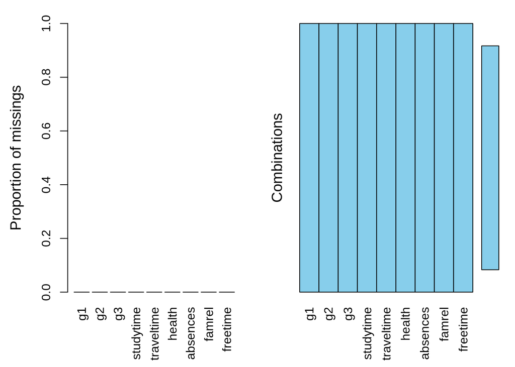

```
##
##  Variables sorted by number of missings:
##    Variable Count
##          g1     0
##          g2     0
##          g3     0
##   studytime     0
##  traveltime     0
##      health     0
##    absences     0
##      famrel     0
##    freetime     0
```

```r
#Output the most common combinations
head(res_math[rev(order(res_math[,2])),])
```

```
##        Combinations Count Percent
## 1 0:0:0:0:0:0:0:0:0   395     100
```

```r
#Create and inspect patterns of missingness
res_portuggese<-summary(VIM::aggr(subdata_por, sortVar=TRUE))$combinations
```

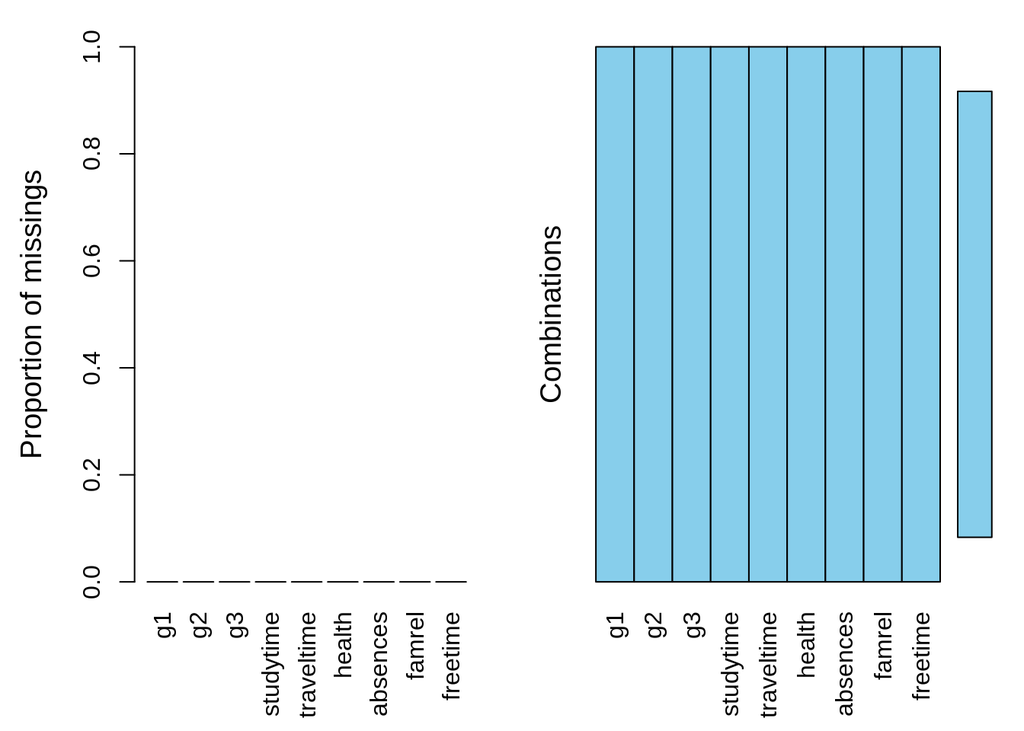

```
##
##  Variables sorted by number of missings:
##    Variable Count
##          g1     0
##          g2     0
##          g3     0
##   studytime     0
##  traveltime     0
##      health     0
##    absences     0
##      famrel     0
##    freetime     0
```

```r
#Output the most common combinations
head(res_portuggese[rev(order(res_portuggese[,2])),])
```

```
##        Combinations Count Percent
## 1 0:0:0:0:0:0:0:0:0   649     100
```

The results show that the variables of interests, no missing data.

# Explore Data

## descriptive statistics

```r
# Center Tendency
variableint <- c("g1", "g2", "studytime", "traveltime","absences")
subdata_math <-stdMathData[variableint]
subdata_por <- stdPorlagData[variableint]
summary(subdata_math)
```

```
##        g1              g2          studytime       traveltime
##  Min.   : 3.00   Min.   : 0.00   Min.   :1.000   Min.   :1.000
##  1st Qu.: 8.00   1st Qu.: 9.00   1st Qu.:1.000   1st Qu.:1.000
##  Median :11.00   Median :11.00   Median :2.000   Median :1.000
##  Mean   :10.91   Mean   :10.71   Mean   :2.035   Mean   :1.448
##  3rd Qu.:13.00   3rd Qu.:13.00   3rd Qu.:2.000   3rd Qu.:2.000
##  Max.   :19.00   Max.   :19.00   Max.   :4.000   Max.   :4.000
##     absences
##  Min.   : 0.000
##  1st Qu.: 0.000
##  Median : 4.000
##  Mean   : 5.709
##  3rd Qu.: 8.000
##  Max.   :75.000
```

```r
summary(subdata_por)
```

```
##        g1             g2          studytime       traveltime
##  Min.   : 0.0   Min.   : 0.00   Min.   :1.000   Min.   :1.000
##  1st Qu.:10.0   1st Qu.:10.00   1st Qu.:1.000   1st Qu.:1.000
##  Median :11.0   Median :11.00   Median :2.000   Median :1.000
##  Mean   :11.4   Mean   :11.57   Mean   :1.931   Mean   :1.569
##  3rd Qu.:13.0   3rd Qu.:13.00   3rd Qu.:2.000   3rd Qu.:2.000
##  Max.   :19.0   Max.   :19.00   Max.   :4.000   Max.   :4.000
##     absences
##  Min.   : 0.000
##  1st Qu.: 0.000
##  Median : 2.000
##  Mean   : 3.659
##  3rd Qu.: 6.000
##  Max.   :32.000
```

```r
## summary variability
pastecs::stat.desc(stdMathData[variableint], basic=F)
```

```
##                      g1         g2  studytime traveltime   absences
## median       11.0000000 11.0000000 2.00000000 1.00000000  4.0000000
## mean         10.9088608 10.7139241 2.03544304 1.44810127  5.7088608
## SE.mean       0.1670068  0.1892618 0.04222676 0.03509527  0.4026794
## CI.mean.0.95  0.3283359  0.3720894 0.08301795 0.06899742  0.7916691
## var          11.0170533 14.1489173 0.70432436 0.48651288 64.0495406
## std.dev       3.3191947  3.7615047 0.83924035 0.69750475  8.0030957
## coef.var      0.3042659  0.3510856 0.41231335 0.48166849  1.4018726
```

```r
pastecs::stat.desc(stdPorlagData[variableint], basic=F)
```

```
##                      g1         g2 studytime traveltime   absences
## median       11.0000000 11.0000000 2.0000000 1.00000000  2.0000000
## mean         11.3990755 11.5701079 1.9306626 1.56856703  3.6594761
## SE.mean       0.1077611  0.1143703 0.0325611 0.02938748  0.1821657
## CI.mean.0.95  0.2116031  0.2245812 0.0639380 0.05770618  0.3577064
## var           7.5364806  8.4892903 0.6880861 0.56049192 21.5366423
## std.dev       2.7452651  2.9136387 0.8295096 0.74866009  4.6407588
## coef.var      0.2408323  0.2518247 0.4296502 0.47728919  1.2681484
```

## Assessing a variable for Normality

Step 1: Assessing by plots Histogram with normal curve QQ-plot checking if it can be normalised Step 2: Summary Statistics including measure of skewness and kurtosis. Step 3: Review statistics by plotting to check whether it close to normal data. Step 4: Report correct statistics depend on the assessment and show the result whether the data can follow the normal distribution.

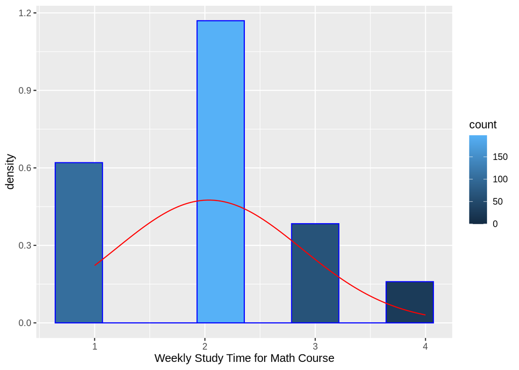

```r
# histogram for math course sample

#study time
histogr_stdtime <- ggplot(stdMathData, aes(x=studytime)) +
                   labs(x="Weekly Study Time for Math Course") +
                   geom_histogram(bins=8, colour="blue", aes(y= ..density.., fill=..count..)) +
                   scale_fill_gradient("count", low="#132B43", high="#56B1F7") +
                   stat_function(fun=dnorm, color="red", args=list(mean=mean(stdMathData$studytime, na.rm=TRUE), sd=sd(stdMathData$studytime, na.rm=TRUE)))

histogr_stdtime
```

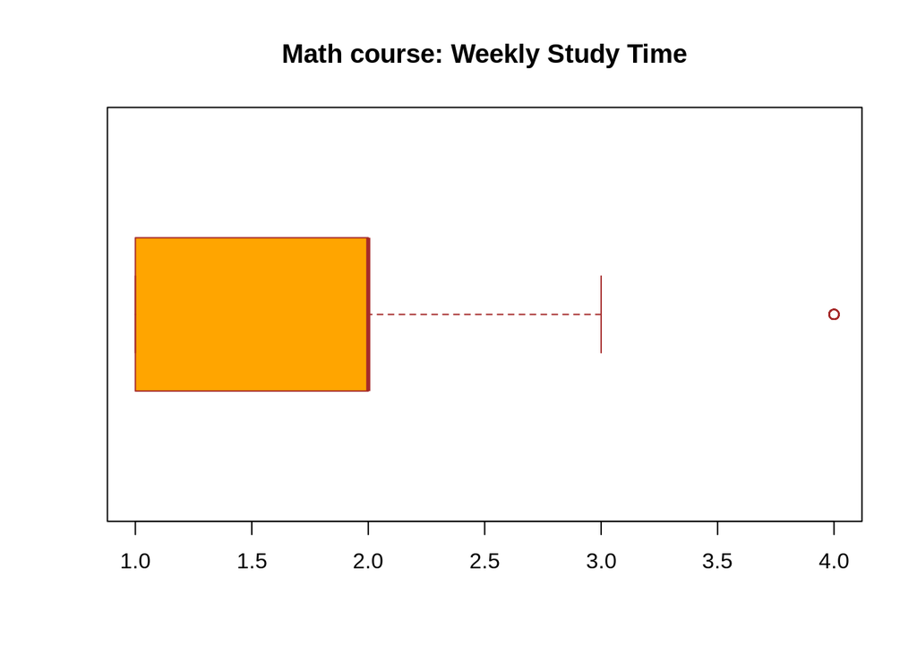

```r
boxplot(stdMathData$studytime,
        main = "Math course: Weekly Study Time",
        col = "orange",
        border = "brown",
        horizontal = TRUE)
```

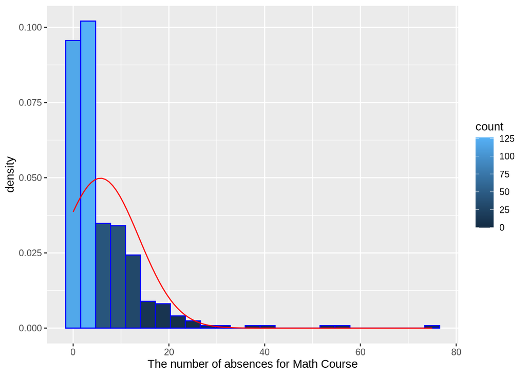

```r
# absences
histogr_ab <- ggplot(stdMathData, aes(x=absences)) +
                   labs(x="The number of absences for Math Course") +
                   geom_histogram(bins=25, colour="blue", aes(y= ..density.., fill=..count..)) +
                   scale_fill_gradient("count", low="#132B43", high="#56B1F7") +
                   stat_function(fun=dnorm, color="red", args=list(mean=mean(stdMathData$absences, na.rm=TRUE), sd=sd(stdMathData$absences, na.rm=TRUE)))
histogr_ab
```

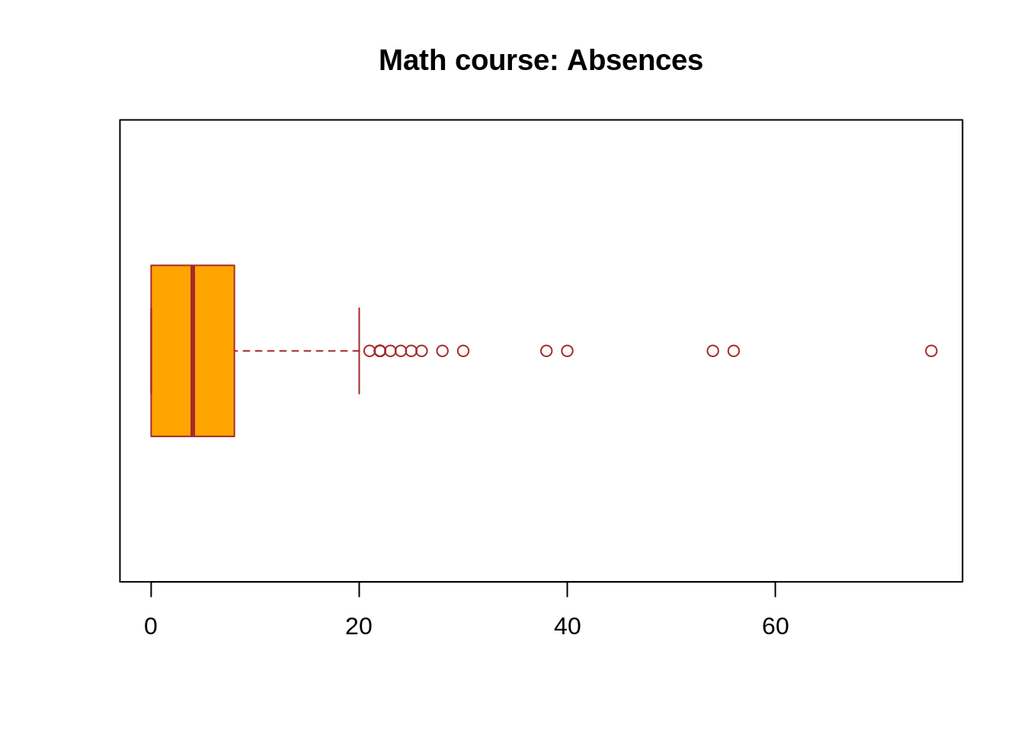

```r
boxplot(stdMathData$absences,
        main = "Math course: Absences",
        #xlab = "Number of absences",
        col = "orange",
        border = "brown",
        horizontal = TRUE)
```

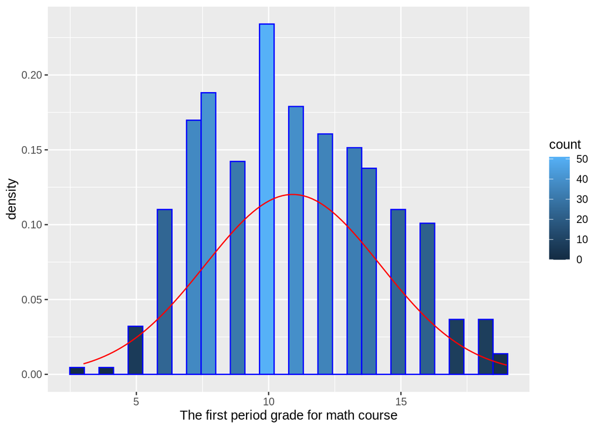

```r
#g1
histogr_g1 <- ggplot(stdMathData, aes(x=g1)) +
                   labs(x="The first period grade for math course") +
                   geom_histogram(bins=30, colour="blue", aes(y= ..density.., fill=..count..)) +
                   scale_fill_gradient("count", low="#132B43", high="#56B1F7") +
                   stat_function(fun=dnorm, color="red", args=list(mean=mean(stdMathData$g1, na.rm=TRUE), sd=sd(stdMathData$g1, na.rm=TRUE)))
histogr_g1
```

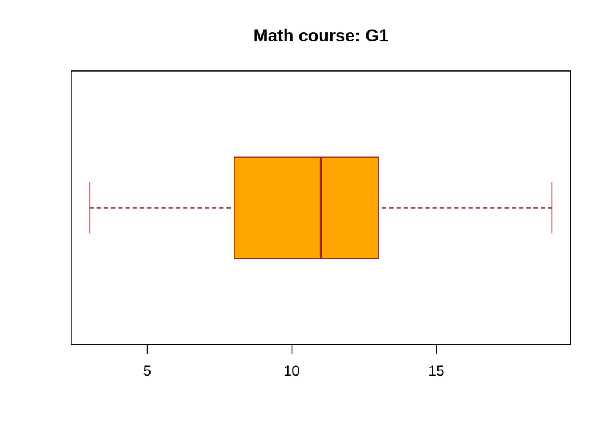

```r
boxplot(stdMathData$g1,
        main = "Math course: G1",
        col = "orange",
        border = "brown",
        horizontal = TRUE)
```

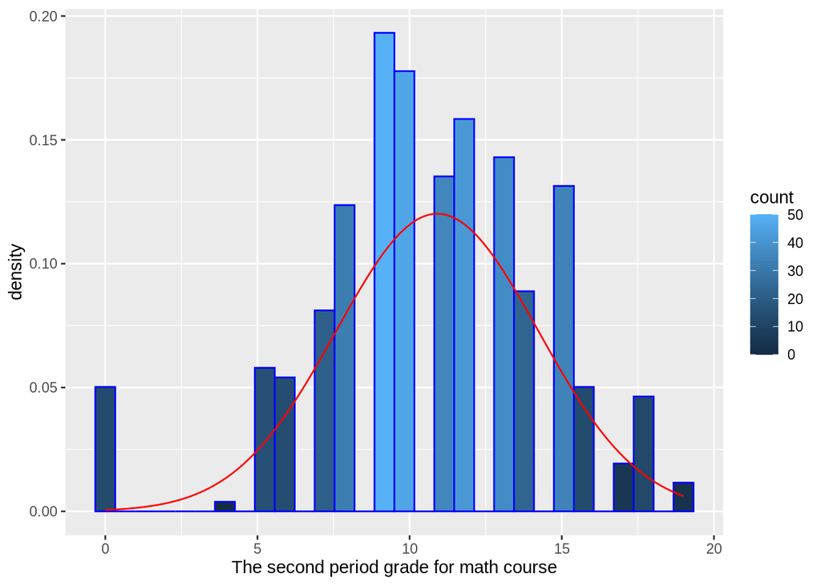

```r
#g2
histogr_g2 <- ggplot(stdMathData, aes(x=g2)) +
                   labs(x="The second period grade for math course") +
                   geom_histogram(bins=30, colour="blue", aes(y= ..density.., fill=..count..)) +
                   scale_fill_gradient("count", low="#132B43", high="#56B1F7") +
                   stat_function(fun=dnorm, color="red", args=list(mean=mean(stdMathData$g1, na.rm=TRUE), sd=sd(stdMathData$g1, na.rm=TRUE)))
histogr_g2
```

[figure not shown]

```r
boxplot(stdMathData$g1,
        main = "Math course: G2",
        col = "orange",
        border = "brown",
        horizontal = TRUE)
```

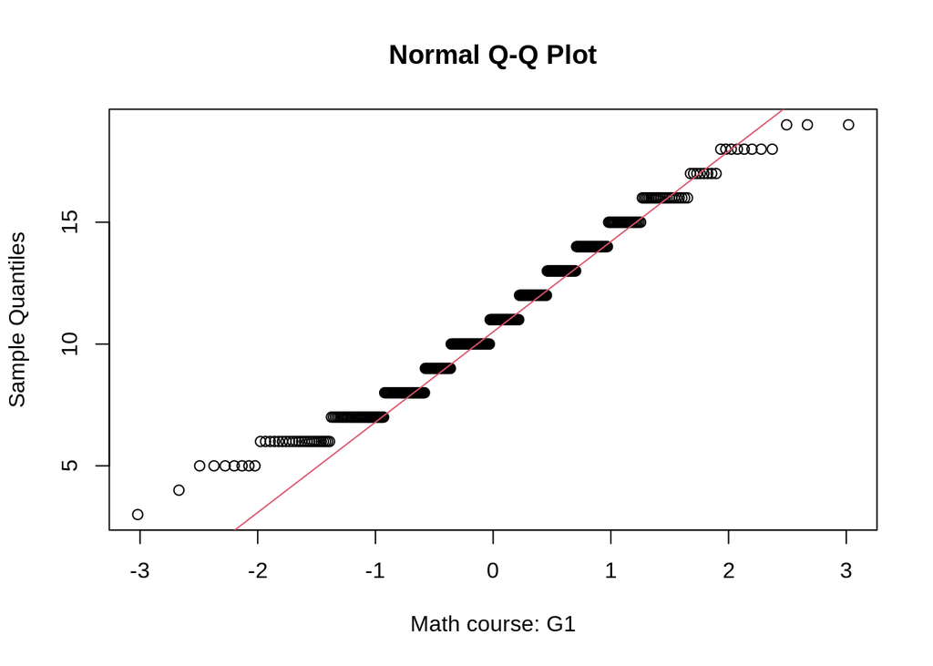

```r
#create qq-plot for g1
qqnorm(stdMathData$g1, xlab = "Math course: G1")
qqline(stdMathData$g1, col=2)
```

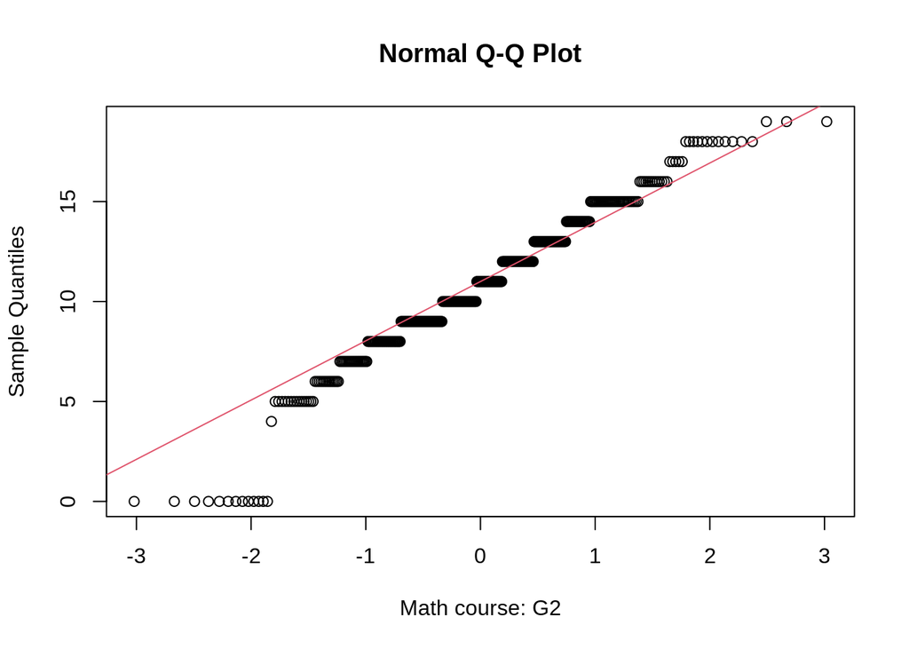

```r
qqnorm(stdMathData$g2, xlab="Math course: G2")
qqline(stdMathData$g2, col=2)
```

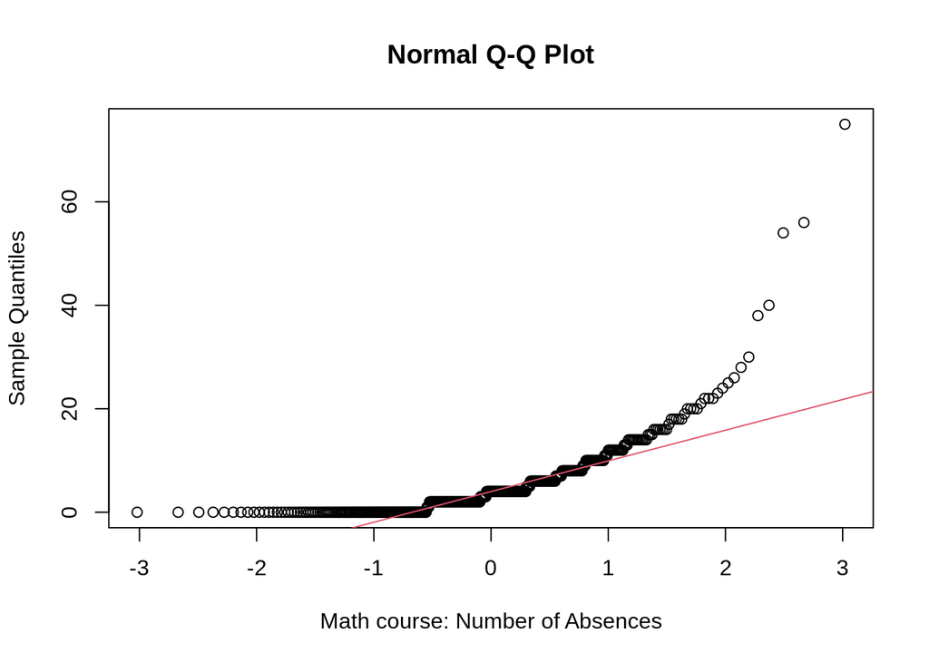

```r
qqnorm(stdMathData$absences, xlab="Math course: Number of Absences")
qqline(stdMathData$absences, col=2)
```

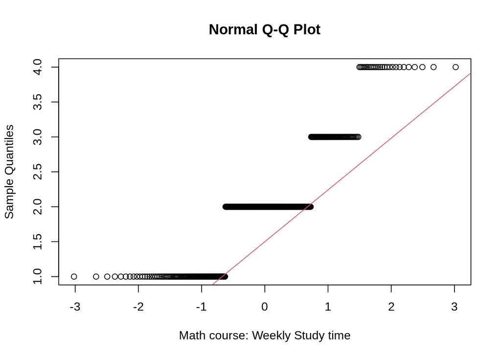

```r
qqnorm(stdMathData$studytime, xlab="Math course: Weekly Study time")
qqline(stdMathData$studytime, col=2)
```

```r
#g1 generae summary statistics
pastecs::stat.desc(stdMathData$g1, basic=F)
```

```
##       median         mean      SE.mean CI.mean.0.95          var      std.dev
##   11.0000000   10.9088608    0.1670068    0.3283359   11.0170533    3.3191947
##     coef.var
##    0.3042659
```

```r
#skewness and kurtosis
tpskew <- semTools::skew(stdMathData$g1)
tpkurt <- semTools::kurtosis(stdMathData$g1)

tpskew
```

```
##  skew (g1)         se          z          p
## 0.24061324 0.12324720 1.95228155 0.05090479
```

```r
tpkurt
```

```
## Excess Kur (g2)              se               z               p
##    -0.693829502     0.246494409    -2.814787991     0.004880942
```

```r
tpskew[1]/tpskew[2]
```

```
## skew (g1)
##  1.952282
```

```r
tpkurt[1]/tpkurt[2]
```

```
## Excess Kur (g2)
##       -2.814788
```

```r
mathg1<- abs(scale(stdMathData$g1))
FSA::perc(as.numeric(mathg1), 1.96, "gt")
```

```
## [1] 3.291139
```

```r
FSA::perc(as.numeric(mathg1), 3.29, "gt")
```

```
## [1] 0
```

```r
#g2 generae summary statistics
pastecs::stat.desc(stdMathData$g2, basic=F)
```

```
##       median         mean      SE.mean CI.mean.0.95          var      std.dev
##   11.0000000   10.7139241    0.1892618    0.3720894   14.1489173    3.7615047
##     coef.var
##    0.3510856
```

```r
#skewness and kurtosis
tpskew <- semTools::skew(stdMathData$g2)
tpkurt <- semTools::kurtosis(stdMathData$g2)

tpskew
```

```
##     skew (g1)            se             z             p
## -0.4316453890  0.1232472045 -3.5022732624  0.0004613062
```

```r
tpkurt
```

```
## Excess Kur (g2)              se               z               p
##      0.62770564      0.24649441      2.54653096      0.01087996
```

```r
tpskew[1]/tpskew[2]
```

```
## skew (g1)
## -3.502273
```

```r
tpkurt[1]/tpkurt[2]
```

```
## Excess Kur (g2)
##        2.546531
```

```r
mathg1<- abs(scale(stdMathData$g2))
FSA::perc(as.numeric(mathg1), 1.96, "gt")
```

```
## [1] 4.050633
```

```r
FSA::perc(as.numeric(mathg1), 3.29, "gt")
```

```
## [1] 0
```

```r
#study time generae summary statistics
pastecs::stat.desc(stdMathData$studytime, basic=F)
```

```
##       median         mean      SE.mean CI.mean.0.95          var      std.dev
##   2.00000000   2.03544304   0.04222676   0.08301795   0.70432436   0.83924035
##     coef.var
##   0.41231335
```

```r
#skewness and kurtosis
tpskew <- semTools::skew(stdMathData$studytime)

tpkurt <- semTools::kurtosis(stdMathData$studytime)

tpskew
```

```
##    skew (g1)           se            z            p
## 6.321422e-01 1.232472e-01 5.129059e+00 2.911939e-07
```

```r
tpkurt
```

```
## Excess Kur (g2)              se               z               p
##     -0.01443182      0.24649441     -0.05854826      0.95331193
```

```r
tpskew[1]/tpskew[2]
```

```
## skew (g1)
##  5.129059
```

```r
tpkurt[1]/tpkurt[2]
```

```
## Excess Kur (g2)
##     -0.05854826
```

```r
mathst<- abs(scale(stdMathData$studytime))
FSA::perc(as.numeric(mathst), 1.96, "gt") #greater >= 1.96
```

```
## [1] 6.835443
```

```r
FSA::perc(as.numeric(mathst), 3.29, "gt") #greater >= 3.29
```

```
## [1] 0
```

```r
#absences generae summary statistics
pastecs::stat.desc(stdMathData$absences, basic=F)
```

```
##       median         mean      SE.mean CI.mean.0.95          var      std.dev
##    4.0000000    5.7088608    0.4026794    0.7916691   64.0495406    8.0030957
##     coef.var
##    1.4018726
```

```r
#skewness and kurtosis
tpskew <- semTools::skew(stdMathData$absences)
tpkurt <- semTools::kurtosis(stdMathData$absences)

#tpskew
#tpkurt

tpskew[1]/tpskew[2]
```

```
## skew (g1)
##  29.79036
```

```r
tpkurt[1]/tpkurt[2]
```

```
## Excess Kur (g2)
##        88.11214
```

```r
mathg1<- abs(scale(stdMathData$absences))

#calculate the percentage that are greater than 1.96
FSA::perc(as.numeric(mathg1), 1.96, "gt")
```

```
## [1] 3.544304
```

```r
# calculate the percentage that are greater than 3.29
FSA::perc(as.numeric(mathg1), 3.29, "gt")
```

```
## [1] 1.265823
```

## Correlation

### 1. The correlation between number of absences (absences) and the first period grade (g1)

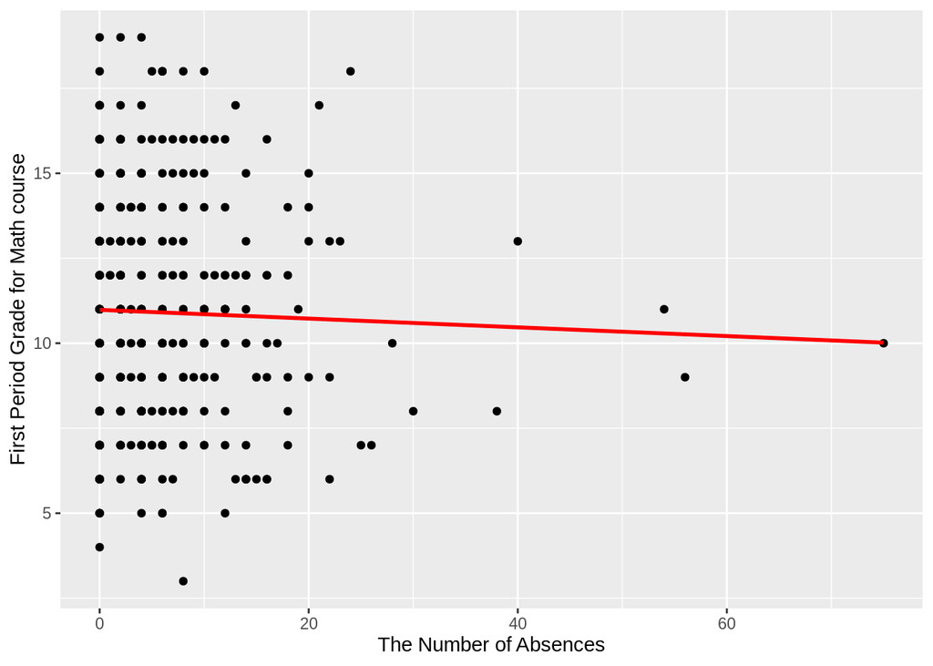

```r
#show scatterplot of the number of absences and the first period grade

scat_g1 <- ggplot(stdMathData, aes(stdMathData$absences,stdMathData$g1)) +
#show regression line
       geom_point() +
       geom_smooth(method="lm", colour="red", se = F) +
       labs(x = "The Number of Absences", y = "First Period Grade for Math course")
scat_g1
```

```r
# Conducting Correlation Tests - Pearson, Spearman, Kendall
# Pearson corrlection test --- Parametric test
# Pearson Correlation  (Parametric)
# Spearman Rank Order Correlation or Kendall’s Tau (Non-Parametric)

#1. Pearson corrlation
stats::cor.test(stdMathData$g1,stdMathData$absences, method='pearson')
```

```
##
##  Pearson's product-moment correlation
##
## data:  stdMathData$g1 and stdMathData$absences
## t = -0.6149, df = 393, p-value = 0.539
## alternative hypothesis: true correlation is not equal to 0
## 95 percent confidence interval:
##  -0.12927845  0.06787576
## sample estimates:
##        cor
## -0.0310029
```

```r
#2. Spearman corrleation to check the missing data if the data does not fit a normal distribution, then we can use spearman or kurtosis
stats::cor.test(stdMathData$g1, stdMathData$absences, method='spearman')
```

```
##
##  Spearman's rank correlation rho
##
## data:  stdMathData$g1 and stdMathData$absences
## S = 10225570, p-value = 0.9293
## alternative hypothesis: true rho is not equal to 0
## sample estimates:
##         rho
## 0.004479359
```

```r
#3. kendall which handle ties
stats::cor.test(stdMathData$g1, stdMathData$absences, method='kendall')
```

```
##
##  Kendall's rank correlation tau
##
## data:  stdMathData$g1 and stdMathData$absences
## z = 0.093068, p-value = 0.9258
## alternative hypothesis: true tau is not equal to 0
## sample estimates:
##         tau
## 0.003461989
```

### 2. The correlation between weekly study time (x) and the first period grade (g1) (y)

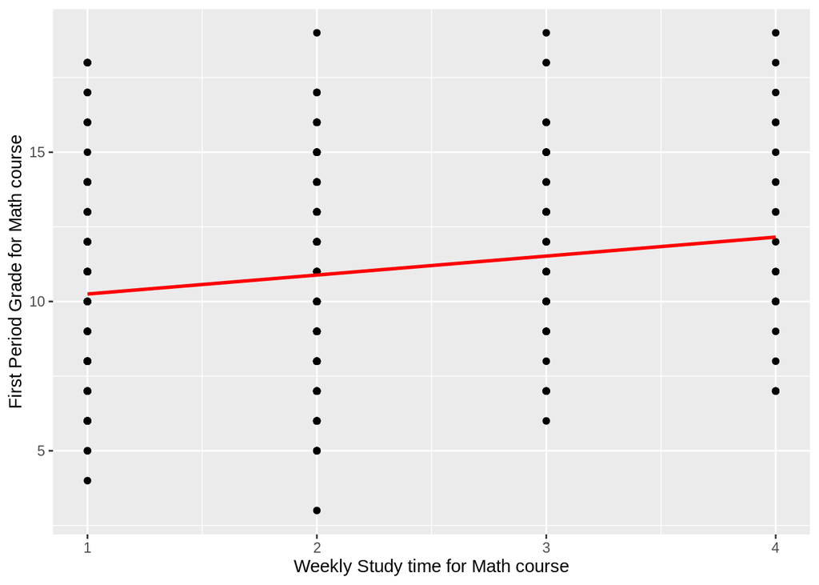

```r
#show scatterplot of the number of studytime and the first period grade
scat_st <- ggplot(stdMathData, aes(stdMathData$studytime,stdMathData$g1)) +
#show regression line
       geom_point() +
       geom_smooth(method="lm", colour="red", se = F) +
       labs(x = "Weekly Study time for Math course", y = "First Period Grade for Math course")
scat_st
```

```r
# Conducting Correlation Tests - Pearson, Spearman, Kendall
# Pearson corrlection test --- Parametric test
# Pearson Correlation  (Parametric)
# Spearman Rank Order Correlation or Kendall’s Tau (Non-Parametric)

#1. Pearson corrlation
stats::cor.test(stdMathData$g1,stdMathData$studytime, method='pearson')
```

```
##
##  Pearson's product-moment correlation
##
## data:  stdMathData$g1 and stdMathData$studytime
## t = 3.2259, df = 393, p-value = 0.001361
## alternative hypothesis: true correlation is not equal to 0
## 95 percent confidence interval:
##  0.06293832 0.25523800
## sample estimates:
##       cor
## 0.1606119
```

```r
#2. Spearman corrleation to check the missing data if the data does not fit a normal distribution, then we can use spearman or kurtosis
stats::cor.test(stdMathData$g1, stdMathData$studytime, method='spearman')
```

```
##
##  Spearman's rank correlation rho
##
## data:  stdMathData$g1 and stdMathData$studytime
## S = 8604647, p-value = 0.00121
## alternative hypothesis: true rho is not equal to 0
## sample estimates:
##      rho
## 0.162286
```

```r
#3. kendall which handle ties
stats::cor.test(stdMathData$g1, stdMathData$studytime,method='kendall')
```

```
##
##  Kendall's rank correlation tau
##
## data:  stdMathData$g1 and stdMathData$studytime
## z = 3.277, p-value = 0.001049
## alternative hypothesis: true tau is not equal to 0
## sample estimates:
##       tau
## 0.1314407
```

### 3. The correlation between second period grade (g2) (y) and the first period grade (g1) (x)

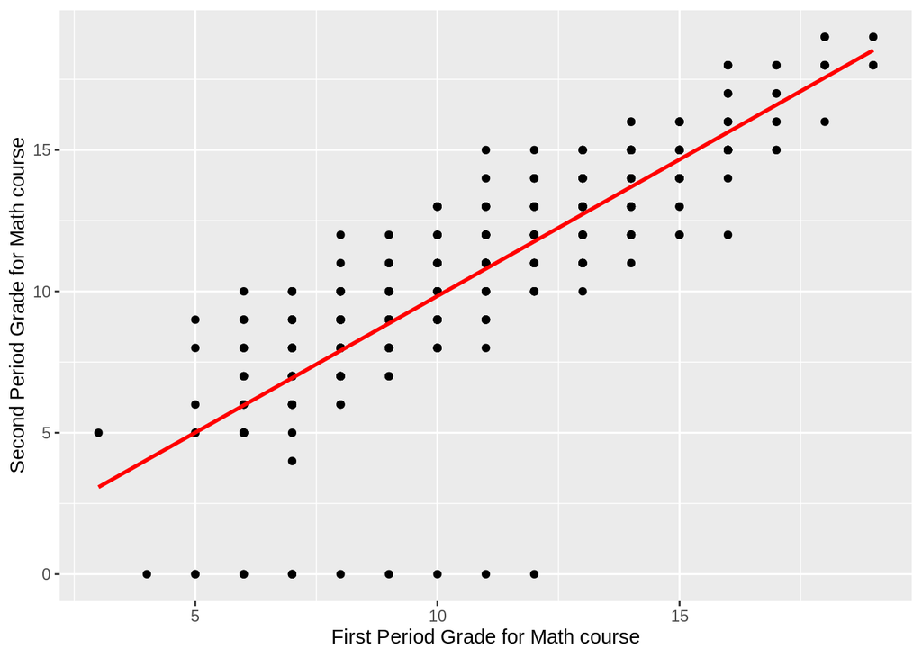

```r
#show scatterplot of second period grade (g2)  (y) and the first period grade (g1) (x)

scat_g2 <- ggplot(stdMathData, aes(stdMathData$g1, stdMathData$g2)) +
#show regression line
       geom_point() +
       geom_smooth(method="lm", colour="red", se = F) +
       labs(x = "First Period Grade for Math course", y = "Second Period Grade for Math course")
scat_g2
```

```r
# Conducting Correlation Tests - Pearson, Spearman, Kendall
# Pearson corrlection test --- Parametric test
# Pearson Correlation  (Parametric)
# Spearman Rank Order Correlation or Kendall’s Tau (Non-Parametric)

#1. Pearson corrlation
stats::cor.test(stdMathData$g2, stdMathData$g1, method='pearson')
```

```
##
##  Pearson's product-moment correlation
##
## data:  stdMathData$g2 and stdMathData$g1
## t = 32.278, df = 393, p-value < 2.2e-16
## alternative hypothesis: true correlation is not equal to 0
## 95 percent confidence interval:
##  0.8226117 0.8770475
## sample estimates:
##       cor
## 0.8521181
```

```r
#2. Spearman corrleation to check the missing data if the data does not fit a normal distribution, then we can use spearman or kurtosis
stats::cor.test(stdMathData$g2, stdMathData$g1, method='spearman')
```

```
##
##  Spearman's rank correlation rho
##
## data:  stdMathData$g2 and stdMathData$g1
## S = 1080656, p-value < 2.2e-16
## alternative hypothesis: true rho is not equal to 0
## sample estimates:
##       rho
## 0.8947916
```

```r
#3. kendall which handle ties
stats::cor.test(stdMathData$g2, stdMathData$g1, method='kendall')
```

```
##
##  Kendall's rank correlation tau
##
## data:  stdMathData$g2 and stdMathData$g1
## z = 21.26, p-value < 2.2e-16
## alternative hypothesis: true tau is not equal to 0
## sample estimates:
##       tau
## 0.7734594
```